# Robust PCA for functional snippets

Hyunsung Kim

2021-04-14

# Preprocessing for AMI data

- $n = 1000$ 가구의 2012.01 ~ 2014.11 까지의 시간별 데이터로 다음의 2단계를 거쳐 preprocessing.
  - 일별 평균 데이터 (`na.rm = TRUE`) 로 변환 (**1038 time points**).
  - 3일별 평균 데이터 (`na.rm = FALSE`) 로 변환 (**346 time points**).
- `-`값을 가지는 극단적으로 잘못 측정된 데이터가 존재하나, 모두 포함한 상태에서 진행.
- 312개 curve가 missing value를 포함.

# Clustering for AMI data

- 다음의 방법을 통해 covariance estimate 후, FPCA 적용 (**4 PCs** 사용).
  - Yao et al. (2005)
  - Huber loss
- 위로부터 얻은 FPC score를 사용하여 $k$-means clustering 적용.
- 우선 결과 확인을 위해 fixed parameter 사용 ($h = 0.2, \delta = 1.345$).
- **4개 clusters**를 가정.

## Clustering results

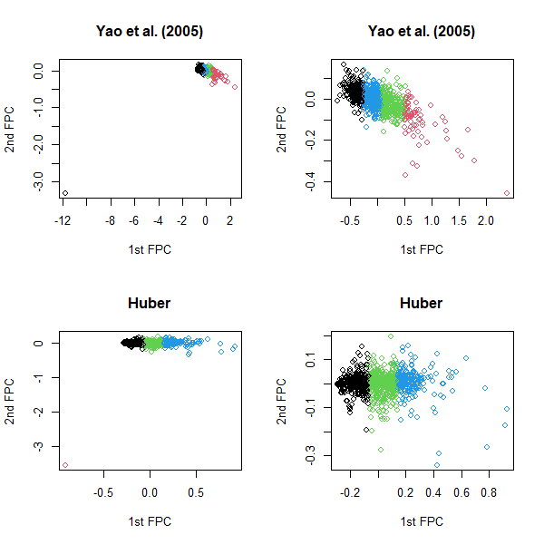

Figure 1. Scatter of first FPC versus second FPC from $k$-means clustering. Right is the figure except for one extreme value on Left.

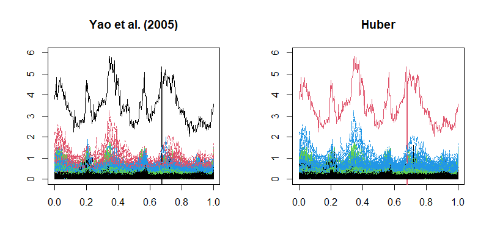

Figure 2. 1000 AMI trajectories between 4 clusters.

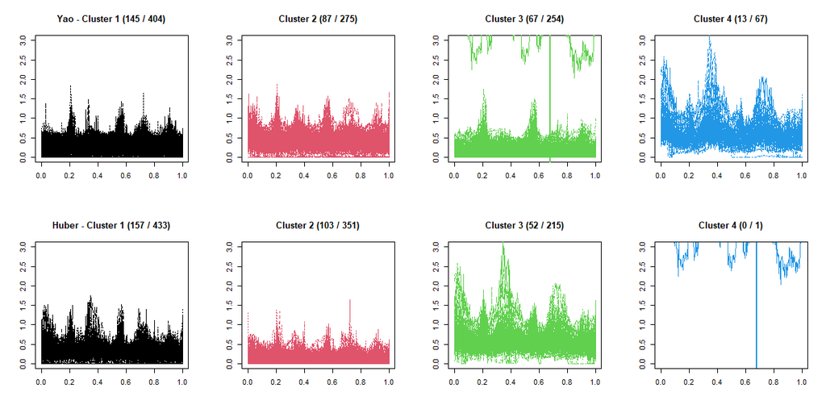

Figure 3. AMI trajectories for each cluster. Parenthesis indicates the number of missing curves and total curves on each cluster.

## Clustering for different number of groups

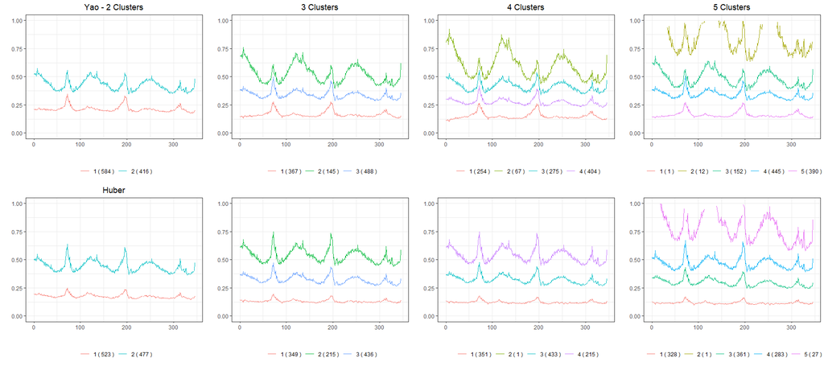

Figure 4. Averaged AMI trajectories for 2 ~ 5 clusters. Parenthesis indicates the number of curves on each cluster.

Table 1. The number of curves assigned to each cluster for different number of groups (# of missing curves / # of total curves).

| Cluster | 2 Clusters Yao | 2 Clusters Huber | 3 Clusters Yao | 3 Clusters Huber | 4 Clusters Yao | 4 Clusters Huber | 5 Clusters Yao | 5 Clusters Huber |
| --- | --- | --- | --- | --- | --- | --- | --- | --- |
| 1 | 189 / 584 | 159 / 523 | 160 / 488 | 159 / 436 | 145 / 404 | 157 / 433 | 144 / 445 | 123 / 361 |
| 2 | 123 / 416 | 153 / 477 | 113 / 367 | 101 / 349 | 87 / 275 | 103 / 351 | 124 / 390 | 95 / 328 |
| 3 | 0 / 0 | 0 / 0 | 39 / 145 | 52 / 215 | 67 / 254 | 52 / 215 | 40 / 152 | 88 / 283 |
| 4 | 0 / 0 | 0 / 0 | 0 / 0 | 0 / 0 | 13 / 67 | 0 / 1 | 4 / 12 | 6 / 27 |
| 5 | 0 / 0 | 0 / 0 | 0 / 0 | 0 / 0 | 0 / 0 | 0 / 0 | 0 / 1 | 0 / 1 |

# Problems

- Time-consuming
  - 방법론 자체가 연산이 오래 걸림에도 불구하고 AMI 자료의 차원이 큰 편임 (Covariance estimation, PCA).
  - 실제 계산을 위해서 51 ~ 101개의 time points로 pre-smoothing을 거쳐 줄이고 시작하는 방법도 있으나, AMI data가 spike가 매우 많은 데이터이기 때문에, covariance estimate 전에 smoothing을 하는 것은 좋지 않을 것으로 보임.
- kCFC를 missing curve에 적용해보려 했으나, 메모리 부족 문제가 발생했고, 100개 curve에 적용하였을 때는 오래 걸려 결과 확인 못함.